# APM 1205: Formative Assessment 1

Part A - Initial Examination of the Data

## Part A – Initial Examination of the Data

### a) Data Inspection and Measurement Roles

```r
# Load the data directly from the online file
url <- "https://raw.githubusercontent.com/resbaz/r-novice-gapminder-files/master/data/gapminder-FiveYearData.csv"
gapminder_all <- read.csv(url)

# Filter for the year 2007
gapminder_2007 <- gapminder_all %>% filter(year == 2007)

# Show rows and columns
dim(gapminder_2007)
```

```
## [1] 142   6
```

- **Dimensions:** The dataset contains **142 observations** (countries) and **6 variables**.
- **Measurement Roles:**
  - `lifeExp` is the **Response Variable ($Y$)**.
  - `gdpPercap` is the **Explanatory Variable ($X$)**.

### b) Numerical Summaries

```r
# Generate basic summary statistics
gapminder_2007 %>%
  select(lifeExp, gdpPercap) %>%
  summary()
```

```
##     lifeExp        gdpPercap
##  Min.   :39.61   Min.   :  277.6
##  1st Qu.:57.16   1st Qu.: 1624.8
##  Median :71.94   Median : 6124.4
##  Mean   :67.01   Mean   :11680.1
##  3rd Qu.:76.41   3rd Qu.:18008.8
##  Max.   :82.60   Max.   :49357.2
```

### c) Graphical Distributions (Histograms)

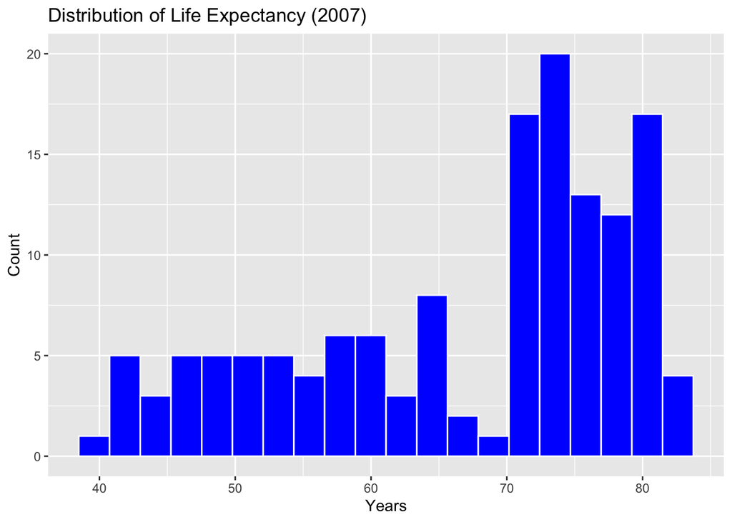

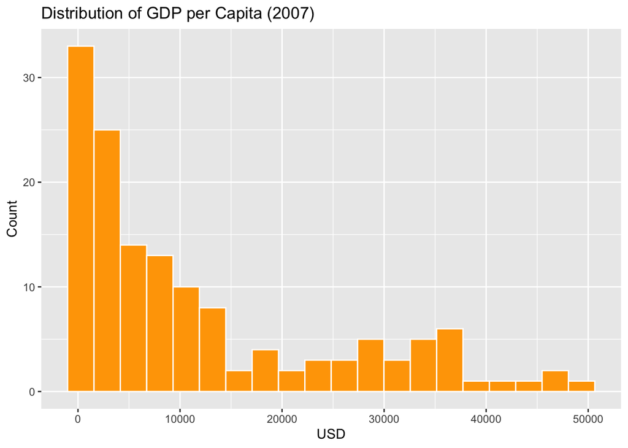

```r
# Histogram for Life Expectancy
ggplot(gapminder_2007, aes(x = lifeExp)) +
  geom_histogram(fill = "blue", color = "white", bins = 20) +
  labs(title = "Distribution of Life Expectancy (2007)", x = "Years", y = "Count")

# Histogram for GDP per Capita
ggplot(gapminder_2007, aes(x = gdpPercap)) +
  geom_histogram(fill = "orange", color = "white", bins = 20) +
  labs(title = "Distribution of GDP per Capita (2007)", x = "USD", y = "Count")
```

- **Shape & Skewness:**
  - **Life Expectancy:** The distribution is **left-skewed** (negatively skewed), as most countries cluster toward the higher end.
  - **GDP per Capita:** The distribution is heavily **right-skewed** (positively skewed), with most countries packed at low income levels and a few rich nations stretching far to the right.

### d) Boxplots and Outliers

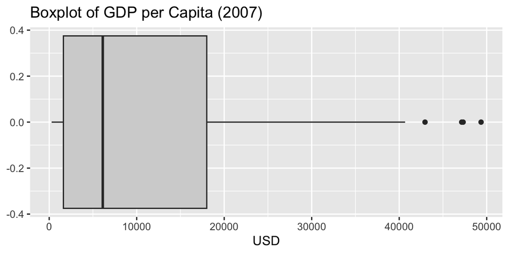

```r
# Boxplot for GDP per Capita to check for outliers
ggplot(gapminder_2007, aes(x = gdpPercap)) +
  geom_boxplot(fill = "lightgray") +
  labs(title = "Boxplot of GDP per Capita (2007)", x = "USD")
```

- **Observations Deserving Further Examination:** The boxplot for `gdpPercap` shows several individual points (dots) past the right whisker boundary. These are extreme **high-income outliers** that will exert an undue pull on a standard linear regression model.